# Analysis on Historical Crime Data for New York City

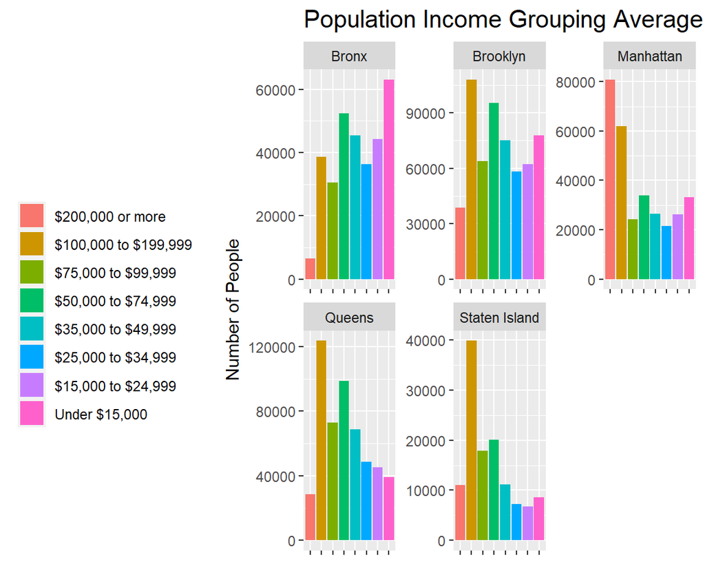

```r
#I wanted a clean view of 15 years summarized so we can see general conditions over time
fifteen_Year_Avg <- family_Income_data

fifteen_Year_Avg <- fifteen_Year_Avg %>%
  group_by(Boroughs, Income.Level) %>%
  summarize(income_avg = mean(Number))

#Reordering my levels on the legend, not having them from greatest to least really bothered me
fifteen_Year_Avg$Income.Level <- factor(fifteen_Year_Avg$Income.Level, levels = c("$200,000 or more",
                                 "$100,000 to $199,999",
                                 "$75,000 to $99,999",
                                 "$50,000 to $74,999",
                                 "$35,000 to $49,999",
                                 "$25,000 to $34,999",
                                 "$15,000 to $24,999",
                                 "Under $15,000"))

#Making the bar plot that limits the amount of years down to just the borough average's
fifteen_Year_Avg_Plot <- fifteen_Year_Avg %>%
  ggplot(mapping = aes(x = Income.Level,
             y = income_avg,
             fill = factor(Income.Level),
             shape = Income.Level)) +
  geom_bar(size = 1, stat = "identity") +
  labs(x = NULL,
       y = "Number of People",
       title = "Population Income Grouping Average") +
  theme(legend.position = "left",
        axis.text.x = element_blank(),
        legend.title = element_blank(),
        plot.title = element_text(size = 15))+
  facet_wrap(~Boroughs, scales = "free")

fifteen_Year_Avg_Plot
```

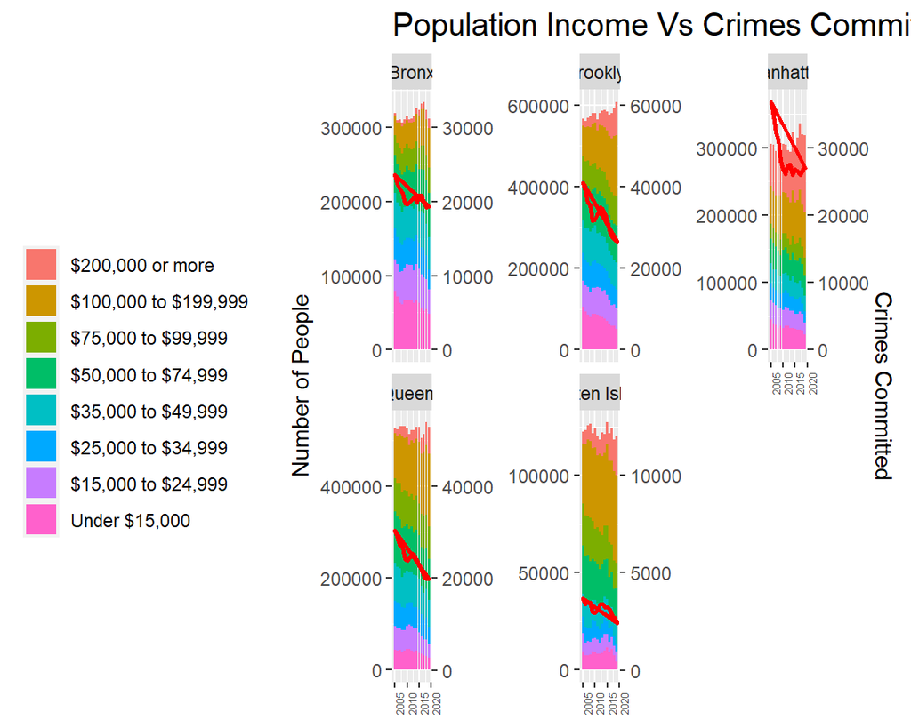

```r
#limit Molly's data to the years I have in mine 2005 to 2019
felony_tot <- subset(hist_felony_by_precinct_data_tot, Year == "2005" | Year == "2006" | Year == "2007" | Year == "2008" | Year == "2009" | Year == "2010" | Year == "2011" | Year == "2012" | Year == "2013" | Year == "2014" | Year == "2015" | Year == "2016" | Year == "2017" | Year == "2018" | Year == "2019")

#Rid the na values
felony_tot <- na.omit(felony_tot)

#Total and match all the years with the total crimes in that borough
felony_tot <- felony_tot %>%
  group_by(Year, Borough) %>%
  mutate(crime_Total = sum(Total)) %>%
  select(-Felony) %>%
  rename(Boroughs = Borough) %>%
  distinct(crime_Total)

felony_tot <- na.omit(felony_tot)

family_Income_data <- family_Income_data %>%
  select(-Level)

crime_Income_Relation <- merge(family_Income_data, felony_tot, by.x = c("Boroughs", "TimeFrame"), by.y = c("Boroughs", "Year"))


#MAKE A BAR AND LINE GRAPH, plotting the line graph atop the income levels to help us see trends
crime_Income_Relation_Plot <- crime_Income_Relation %>%
  ggplot(mapping = aes(x = TimeFrame,
             fill = factor(Income.Level))) +
  geom_bar(aes(y=Number), size = 1, stat = "identity") +
  geom_line(aes(y = 10*crime_Total), size = 1, color="red", group = 1, stat = "identity") +
  scale_y_continuous(sec.axis = sec_axis(~.*0.1, name = "Crimes Committed")) +
  labs(x = NULL,
       y = "Number of People",
       title = "Population Income Vs Crimes Committed that Year") +
  theme(legend.position = "left",
        axis.text.x = element_text(angle = 90,
                                   size = 5),
        legend.title = element_blank(),
        plot.title = element_text(size = 15))+
  facet_wrap(~Boroughs, scale = "free_y")

crime_Income_Relation_Plot
```

# trayed

#Census data

```r
#todo: draw more demographic data from census
# page <- read_html(
#   "https://www.census.gov/quickfacts/fact/table/NY,newyorkcountynewyork,kingscountynewyork,queenscountynewyork,richmondcountynewyork,bronxcountynewyork/PST045219")
# page %>% xml2::xml_structure()
#
# county_name <- page %>%
#   html_nodes(".qf-persist span") %>%
#   html_text() %>%
#   str_replace(", New York", "")
#
# county_population <- page %>%
#   html_nodes(".icon-user-3~ tbody .selected td+ td") %>%
#   html_text() %>%
#   trimws() %>%
#   str_remove_all(",") %>%
#   as.numeric() %>%
#   glimpse()
#
# poverty_level <- page %>%
#   html_nodes("tbody:nth-child(14) .fact~ .fact+ .fact td+ td") %>%
#   html_text() %>%
#   trimws() %>%
#   str_sub(4) %>%
#   str_remove("%") %>%
#   as.numeric() %>%
#   glimpse()
#
# Borough_name <- c("New York Total", "Manhattan", "Brooklyn", "Queens",
#                   "Staten Island", "Bronx")
#
# NY_Census <- tibble(borough = Borough_name, county = county_name,
#                     Population = county_population,
#                     `poverty level` = poverty_level)
#
# NY_Census %>%
#   write.csv("data/NYC_census_data.csv")

NY_census <- read.csv(file = "data/NYC_census_data.csv") %>%
  select(2:5)
```

#Temporary map (only reports population in borough)

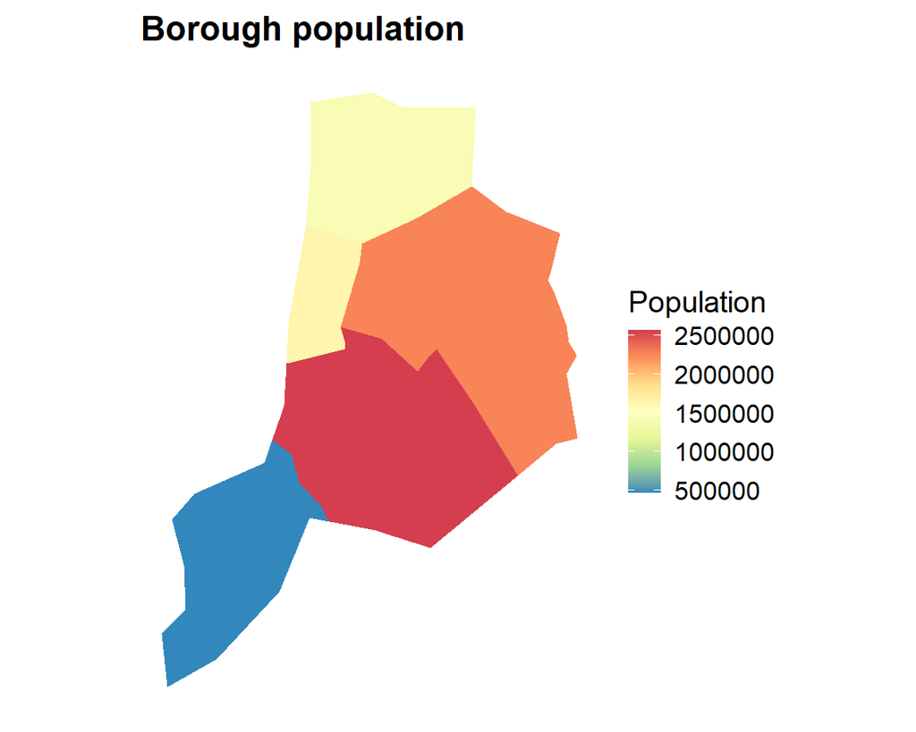

```r
us_states <- us_map("state")%>%
  rename(state = abbr)%>%
  rename(long = x)%>%
  rename(lat = y)

counties <- us_map("counties")

countiesNY <- counties %>%
  filter(abbr == "NY")

county_map <- left_join(countiesNY, NY_census, by = "county") %>%
  na.omit() %>%
  rename(long = x, lat = y)

county_map %>%
  ggplot(mapping = aes( x = long, y = lat, group = group, fill = Population))+
  geom_polygon()+
  scale_color_distiller(palette = "Spectral", aesthetics = "fill")+
  theme_map()+
  coord_equal()+
  labs(title = "Borough population")+
  theme_map()
```

#handgun permit (borough) data

```r
#https://www.nydailynews.com/new-york/ny-nypd-gun-ownership-data-20210517-jfodywqu25bvrijmcrtcaocpn4-story.html
gun_ownership_borough <- read_csv("data/handgun_permits.csv") %>%
  select(3:6) %>%
  rename(count = `Count by Zip code`)

gun_ownership_borough <- gun_ownership_borough %>%
  group_by(County) %>%
  mutate(sum = sum(count))

gun_ownership_borough$County <- gun_ownership_borough$County %>%
  trimws() %>%
  str_to_title() %>%
  paste("County", sep = " ")

gun_ownership_borough <- gun_ownership_borough %>%
  select(1,5) %>%
  rename(county = County)
```

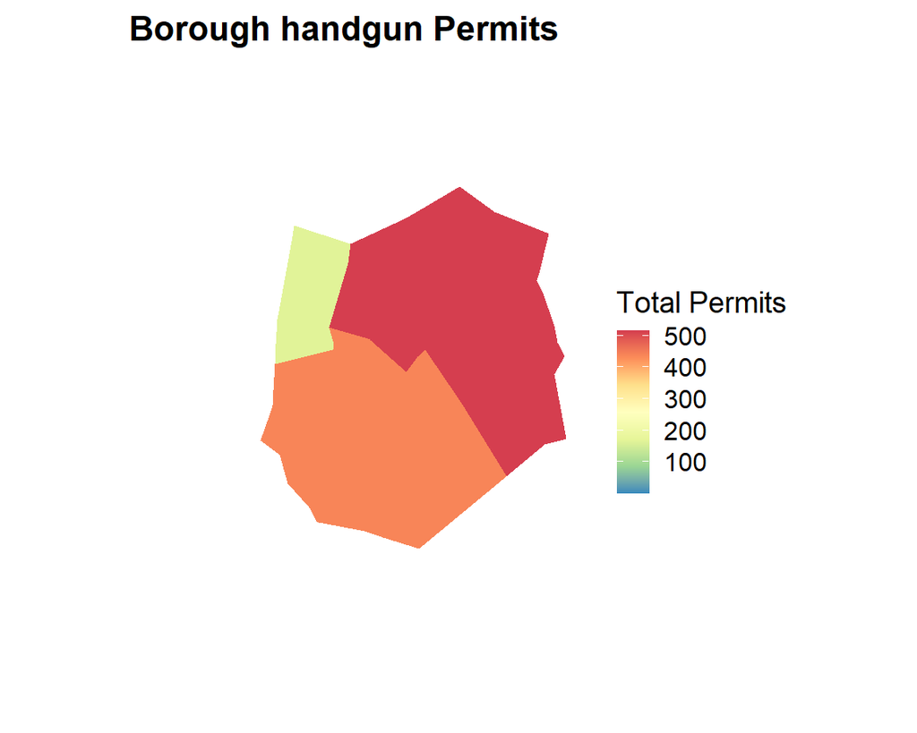

```r
gun_borough_map <- left_join(gun_ownership_borough, county_map,  by = "county")

gun_borough_map %>%
  ggplot(mapping = aes( x = long, y = lat, group = group, fill = sum))+
  geom_polygon()+
  scale_color_distiller(palette = "Spectral", aesthetics = "fill")+
  theme_map()+
  coord_equal()+
  labs(title = "Borough handgun Permits", fill = "Total Permits")+
  theme_map()
```

#gun ownership (state) data

```r
gun_US <- read_csv("data/Gun_ownership_state.csv") %>%
  #https://worldpopulationreview.com/state-rankings/gun-ownership-by-state
  rename(full = State) %>%
  rename(sum = totalGuns) %>%
  select(1,3)

gun_US %>%
  rename(State = full,`Total Guns` = sum) %>%
  arrange(desc(`Total Guns`)) %>%
  datatable(options = list(pageLength = 5))
```

|  | State | Total Guns |
| --- | --- | --- |
| 1 | Texas | 588696 |
| 2 | California | 344622 |
| 3 | Florida | 343288 |
| 4 | Virginia | 307822 |
| 5 | Pennsylvania | 236377 |
| 6 | Georgia | 190050 |
| 7 | Arizona | 179738 |
| 8 | Ohio | 173405 |
| 9 | Alabama | 161641 |
| 10 | North Carolina | 152238 |

[output cut: 40 more lines]

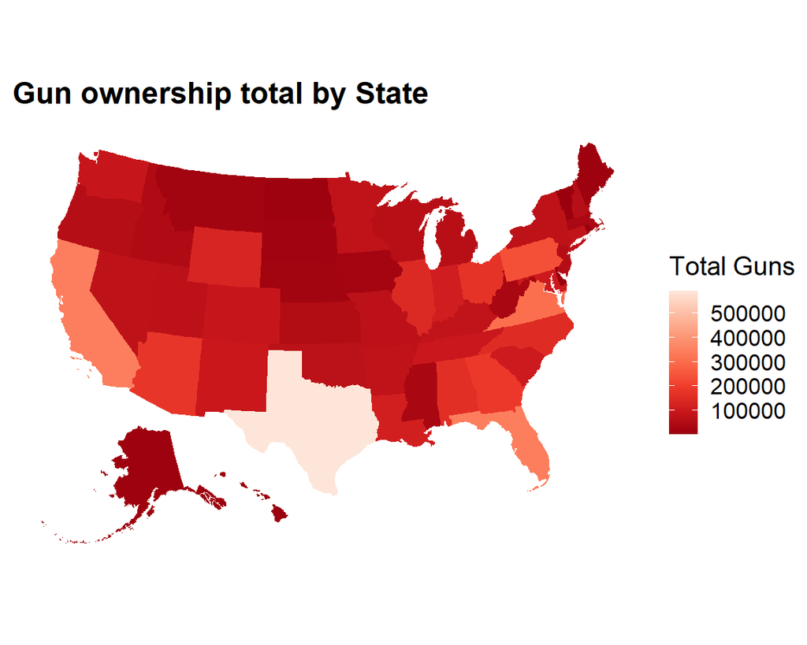

```r
#Todo use much more detailed chloropleth map. ggplot for placeholding.
gun_mapUS <- left_join(gun_US, us_states, by = "full")
gun_mapUS %>%
  ggplot(mapping = aes( x = long, y = lat, group = group, fill = sum))+
  geom_polygon()+
  scale_color_distiller(palette = "Reds", aesthetics = "fill")+
  theme_map()+
  coord_equal()+
  labs(title = "Gun ownership total by State", fill = "Total Guns")+
  theme_map()
```

Sources: NYC.gov: Historical New York City Crime Data: Citywide Seven Major Felony Offenses 2000-2020 & Historical New York City Crime Data: Citywide Seven Major Felony Offenses by Precinct 2000-2020 https://www1.nyc.gov/site/nypd/stats/crime-statistics/historical.page NYCOpen: New York City Population by Borough, 1950 - 2040 https://data.cityofnewyork.us/City-Government/New-York-City-Population-by-Borough-1950-2040/xywu-7bv9 Github: nyc by zachcb https://github.com/zachcp/nycmaps U.S. Census Bureau: Census data for NY boroughs https://www.census.gov/quickfacts/newyorkcitynewyork